# TP STUDENT_PERFORMANCE GROUPE 06

### Maintenant nous allons éffectuer une analyse baser sur les données où il sont le plus centrées c'est à dire entre le prémier quartile et le troisième de chaque variable respectives

### 'math score' 57 - 77

### ' reading score' 59 - 79

### 'writing score' 57 - 79

```python
# Division des données en 2 échantillons distint

conc_data_with=data.loc[(data['math score'] >= 57)  & (data['reading score'] >= 59) & (data['writing score'] >= 57)]
```

```python
conc_data_without = conc_data_with.loc[(conc_data_with['math score'] <= 77)  & (conc_data_with['reading score'] <= 79) & (conc_data_with['writing score'] <= 79)]
```

```python
conc_data_with.shape
```

```
(666, 11)
```

```python
conc_data_without.shape
```

```
(325, 11)
```

```python
conc_data_with.shape[0]/data.shape[0] *100
```

```
66.60000000000001
```

```python
conc_data_without.shape[0]/data.shape[0]*100
```

```
32.5
```

### Nous vennons de créer échantillons qui contientents les données centrés de notre jeu de données

1. conc_data_with : c'est un échantillons de données avec des données supérieurs a 57 juste
2. conc_data_without : c'est un échantillons de données avec des données supérieurs a 57 et inférieur à 80 en terme de notes d'étudiant.
3. conc_data_with contient 66.6% des informations du dataset initial
4. conc_data_without contient 32.5% d'infos
5. Le but c'est de trouver une/des intuition(s) et la(les) comparé(e)(s) avec les résultats obtenue plus haut.

```python
conc_data_with.describe()
```

|  | math score | reading score | writing score |
| --- | --- | --- | --- |
| count | 666.000000 | 666.000000 | 666.000000 |
| mean | 73.878378 | 76.870871 | 76.016517 |
| std | 10.386888 | 9.807692 | 10.143839 |
| min | 57.000000 | 59.000000 | 57.000000 |
| 25% | 65.000000 | 69.250000 | 68.000000 |
| 50% | 73.000000 | 76.000000 | 75.000000 |
| 75% | 81.000000 | 84.000000 | 82.000000 |
| max | 100.000000 | 100.000000 | 100.000000 |

```python
# Analysons les pourcentage réprésenter dans notre échantillons excellent
print('Affichons une description de l\'échantillons conc_data_with')

col = ['gender', 'race/ethnicity', 'parental level of education', 'lunch',
       'test preparation course']

for var in col:
    ans=conc_data_with[var].value_counts(normalize=True)*100
    print(ans)
    print('\n')
```

```
Affichons une description de l'échantillons conc_data_with
female    54.054054
male      45.945946
Name: gender, dtype: float64


group C    30.780781
group D    28.078078
group B    17.717718
group E    16.666667
group A     6.756757
Name: race/ethnicity, dtype: float64


some college          24.624625
associate's degree    22.672673
high school           16.666667
some high school      16.366366
bachelor's degree     13.363363
master's degree        6.306306
Name: parental level of education, dtype: float64


standard        73.423423
free/reduced    26.576577
Name: lunch, dtype: float64


none         57.957958
completed    42.042042
Name: test preparation course, dtype: float64
```

```python
conc_data_without.describe()
```

|  | math score | reading score | writing score |
| --- | --- | --- | --- |
| count | 325.000000 | 325.000000 | 325.000000 |
| mean | 66.578462 | 69.489231 | 68.670769 |
| std | 5.608429 | 5.224353 | 5.750409 |
| min | 57.000000 | 59.000000 | 57.000000 |
| 25% | 62.000000 | 66.000000 | 64.000000 |
| 50% | 66.000000 | 70.000000 | 69.000000 |
| 75% | 71.000000 | 74.000000 | 74.000000 |
| max | 77.000000 | 79.000000 | 79.000000 |

```python
# Analysons les pourcentage réprésenter dans notre échantillons excellent
print('Affichons une description de l\'échantillons conc_data_without')

col = ['gender', 'race/ethnicity', 'parental level of education', 'lunch',
       'test preparation course']

for var in col:
    ans=conc_data_without[var].value_counts(normalize=True)*100
    print(ans)
    print('\n')
```

```
Affichons une description de l'échantillons conc_data_without
female    50.769231
male      49.230769
Name: gender, dtype: float64


group C    31.692308
group D    29.538462
group B    18.153846
group E    13.538462
group A     7.076923
Name: race/ethnicity, dtype: float64


some college          26.769231
high school           21.538462
associate's degree    19.384615
some high school      16.923077
bachelor's degree     11.384615
master's degree        4.000000
Name: parental level of education, dtype: float64


standard        68.615385
free/reduced    31.384615
Name: lunch, dtype: float64


none         65.846154
completed    34.153846
Name: test preparation course, dtype: float64
```

| race/ethnicity | math score | reading score | writing score |
| --- | --- | --- | --- |
| group A | 71.955556 | 76.244444 | 73.844444 |
| group B | 72.084746 | 76.194915 | 74.466102 |
| group C | 72.473171 | 76.921951 | 76.151220 |
| group D | 73.791444 | 76.401070 | 76.759358 |
| group E | 79.306306 | 78.540541 | 77.045045 |

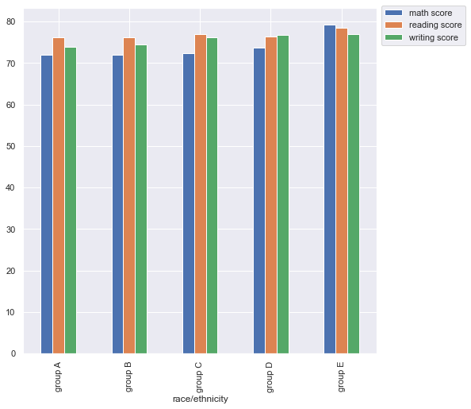

```python
conc_data_with.groupby(['race/ethnicity']).mean().plot(kind='bar')
plt.legend(bbox_to_anchor=(1, 1.02))
conc_data_with.groupby(['race/ethnicity']).mean()
```